# Fastsae: High-Performance Frequentist and Bayesian Small Area Estimation in R

Small area estimation (SAE) plays a pivotal operational role in official statistics, enabling the production of reliable disaggregated socioeconomic, health, and demographic indicators when domain-specific sample sizes are small or zero. However, practitioners in national statistical offices (NSOs) face a triple computational and operational barrier: frequentist spatial and spatio-temporal models with bootstrap mean squared error (MSE) estimation suffer from severe memory bottlenecks and slow runtimes in interpreted languages; non-Gaussian indicators (such as rates, skewed expenditures, and counts) traditionally require computationally demanding Markov chain Monte Carlo (MCMC) algorithms that impede routine production; and model estimates often fail to aggregate to published higher-level totals, violating institutional consistency. We introduce fastsae, an R package engineered for high-performance frequentist and Bayesian small area estimation. On the frequentist side, fastsae implements optimized C++17 routines via RcppArmadillo paired with OpenMP multi-threading, accelerating the classical Fay-Herriot, spatial Fay-Herriot, spatio-temporal Fay-Herriot, and unit-level Battese-Harter-Fuller models alongside their analytical and bootstrap MSE estimators. On the Bayesian side, fastsae provides a unified empirical best prediction (EBP) interface across six distribution families (Gaussian, Beta, Gamma, Binomial, Poisson, Negative Binomial), fitted by Integrated Nested Laplace Approximations (INLA) by default or by MCMC in Python (JAX/NumPyro) through interchangeable engine objects. Crucially, fastsae introduces exact survey dispersion mappings that respect design-based direct sampling variances and accommodates modern spatial priors (BYM, scaled BYM2, Leroux CAR, and SLM) as well as Knorr-Held space-time interaction dynamics. To bridge estimation and dissemination, the package features a two-stage hierarchical benchmarking engine for simultaneous provincial and national calibration, an automated reliability classification engine aligned with NSO standards, multi-model concordances, automated ggplot2 spatial mapping, and multi-sheet spreadsheet exports. Extensive benchmarks and finite population Monte Carlo simulations demonstrate large computational speedups at 1,000 domains (1,263x for Fay-Herriot and 67x for spatial Fay-Herriot relative to sae, 217x for spatial Beta relative to Stan-based MCMC) and reductions of more than 99% in allocated memory, without loss of inferential precision.

Ridson Al Farizal P. (Department of Computational Statistics, Politeknik Statistika STIS) , Azka Ubaidillah (Department of Statistics, Politeknik Statistika STIS)  
2026-10-14

In modern evidence-based governance, policy interventions are increasingly decentralized. Monitoring the United Nations Sustainable Development Goals (SDGs), allocating municipal fiscal transfers, targeting social safety net subsidies, and responding to localized disease outbreaks all require dependable statistical indicators at highly disaggregated geographic administrative levels . However, national statistical offices (NSOs) face structural sample size limitations. Large-scale household surveys—such as the American Community Survey (ACS) in the United States, the European Union Statistics on Income and Living Conditions (EU-SILC), and the National Socioeconomic Survey (Susenas) in Indonesia—are powered to yield acceptable sampling errors only at national or broad regional levels. When partitioned into sub-domains (e.g., municipalities, districts, or health zones), domain-specific sample sizes become sparse or zero, causing direct survey estimators to suffer from high sampling variance and unacceptable coefficients of variation .

Small area estimation (SAE) overcomes these limitations by ``borrowing strength’’ across domains and time periods via linking models that combine survey responses with auxiliary administrative registers, census aggregates, or geospatial layers . The cornerstone of this literature remains the area-level Fay-Herriot (FH) model , extended to account for spatial dependencies via Simultaneous Autoregressive (SAR) structures and temporal dynamics via panel autoregressive processes . In the presence of micro-level auxiliary data, the nested error regression model of (BHF) provides unit-level empirical best linear unbiased predictors (EBLUP).

Let $m$ denote the number of small areas indexed by $i = 1, \dots, m$. The classical area-level model is defined by: %
$$\begin{equation} \label{eq:fh_model}
y_i = \bm{x}_i^\top \bm{\beta} + u_i + e_i, \quad u_i \overset{\mathrm{iid}}{\sim} \mathcal{N}(0, \sigma_u^2), \quad e_i \overset{\mathrm{ind}}{\sim} \mathcal{N}(0, D_i),
\end{equation}$$
% where $y_i$ is the design-based direct estimator of the target indicator $\theta_i$, $\bm{x}_i$ is a $p \times 1$ vector of auxiliary covariates, $D_i$ is the known design variance, and $u_i$ is the area random effect. The Empirical Best Linear Unbiased Predictor (EBLUP) is given by: %
$$\begin{equation} \label{eq:fh_eblup}
\hat{\theta}_i = \hat{\gamma}_i y_i + (1 - \hat{\gamma}_i) \bm{x}_i^\top \hat{\bm{\beta}}, \quad \hat{\gamma}_i = \frac{\hat{\sigma}_u^2}{\hat{\sigma}_u^2 + D_i},
\end{equation}$$
% where $\hat{\bm{\beta}} = (\bm{X}^\top \hat{\bm{V}}^{-1} \bm{X})^{-1} \bm{X}^\top \hat{\bm{V}}^{-1} \bm{y}$ with $\bm{V} = \mathrm{diag}(\sigma_u^2 + D_1, \dots, \sigma_u^2 + D_m)$. Mean squared error is evaluated via the second-order Prasad-Rao approximation : %
$$\begin{equation} \label{eq:fh_mse}
\mathrm{MSE}(\hat{\theta}_i) \approx g_{1i}(\hat{\sigma}_u^2) + g_{2i}(\hat{\sigma}_u^2) + 2 g_{3i}(\hat{\sigma}_u^2).
\end{equation}$$

To accommodate spatial dependence across contiguous domains, and modeled the area random effects $\bm{u} = (u_1, \dots, u_m)^\top$ via a Simultaneous Autoregressive (SAR) process: %
$$\begin{equation} \label{eq:sfh_sar}
\bm{u} = \rho \bm{W} \bm{u} + \bm{\epsilon}, \quad \bm{\epsilon} \sim \mathcal{N}_m(\bm{0}, \sigma_1^2 \bm{I}_m),
\end{equation}$$
% where $\rho$ is the spatial autoregressive parameter and $\bm{W}$ is a row-standardized spatial proximity matrix. The marginal covariance matrix is $\bm{V}(\sigma_1^2, \rho) = \bm{G}(\sigma_1^2, \rho) + \bm{D}$, where $\bm{G}(\sigma_1^2, \rho) = \sigma_1^2 [(\bm{I}_m - \rho \bm{W})^\top (\bm{I}_m - \rho \bm{W})]^{-1}$. The spatial EBLUP is: %
$$\begin{equation} \label{eq:sfh_eblup}
\hat{\bm{\theta}} = \bm{X} \hat{\bm{\beta}} + \hat{\bm{G}} \hat{\bm{V}}^{-1} (\bm{y} - \bm{X} \hat{\bm{\beta}}).
\end{equation}$$
% The SAR process is defined on all domains of $\bm{W}$, including unsampled ones, which are predicted by spatial kriging. Variance components $(\sigma_1^2, \rho)$ are estimated by REML or ML Fisher scoring with $|\rho| \le 0.999$, falling back to a constrained (projected) Fisher scoring when the classical iteration ends at a negative variance. All quantities are obtained from sparse Cholesky factorizations of $\bm{A} = (\bm{I} - \rho\bm{W})^\top(\bm{I} - \rho\bm{W})$ and $\bm{A} + \sigma_1^2 \bm{E}^\top \bm{D}^{-1} \bm{E}$ through the Woodbury identity, so no dense $m \times m$ inverse is formed. Mean squared error uses the same second-order approximation $g_1 + g_2 + 2g_3 - g_4$ as sae , or parametric and non-parametric bootstrap.

When small area data are collected across longitudinal waves $t = 1, \dots, T$, borrowing strength across space and time yields substantial efficiency gains : %
$$\begin{equation} \label{eq:stfh_model}
y_{it} = \bm{x}_{it}^\top \bm{\beta} + u_{1,it} + u_{2,it} + e_{it},
\end{equation}$$
% where $\bm{u}_1 = \rho_1 \bm{W} \bm{u}_1 + \bm{\epsilon}_1$ is a spatial SAR effect that is constant over time within each area ($u_{1,it} = u_{1,i}$) and $u_{2,it} = \rho_2 u_{2,i,t-1} + \epsilon_{2,it}$ follows an AR(1) temporal process with $|\rho_2| < 1$, as in . In fastsae, the covariance $\bm{V} = \bm{A} + \bm{Z}\bm{V}_{u_1}\bm{Z}^\top$ (with $\bm{A}$ block diagonal in $T \times T$ blocks) is never formed: REML scores, Fisher information, and the analytical MSE ($g_1 + g_2 + 2g_3 - g_4$) are computed from $T \times T$, $D \times D$, and low-rank $DT \times (D + p)$ pieces via the Woodbury identity.

When unit microdata are accessible alongside population auxiliary totals, fastsae implements the nested error regression model : %
$$\begin{equation} \label{eq:bhf_model}
y_{dj} = \bm{x}_{dj}^\top \bm{\beta} + u_d + e_{dj}, \quad d = 1, \dots, D, \quad j = 1, \dots, n_d,
\end{equation}$$
% yielding EBLUP predictors $\hat{\bar{Y}}_d = f_d \bar{y}_d + (1 - f_d)(\bar{\bm{X}}_{d, r}^\top \hat{\bm{\beta}} + \hat{\gamma}_d (\bar{y}_d - \bar{\bm{x}}_d^\top \hat{\bm{\beta}}))$, where $f_d = n_d / N_d$.

For non-Gaussian indicators, fastsae formulates small area estimation within the Latent Gaussian Model (LGM) framework : %
$$\begin{equation} \label{eq:lgm_formulation}
y_i \mid \eta_i, \bm{\theta} \sim \pi(y_i \mid \eta_i, \bm{\theta}), \quad \eta_i = g(\mu_i) = \bm{x}_i^\top \bm{\beta} + u_i + v_i,
\end{equation}$$
% where $g(\cdot)$ is a monotone link function, $v_i \overset{\mathrm{iid}}{\sim} \mathcal{N}(0, \tau_v^{-1})$ is an unstructured effect, and $\bm{u} \sim \mathcal{N}(\bm{0}, \bm{Q}^{-1}(\bm{\theta}_s))$ is a spatial Gaussian Markov Random Field (GMRF). By default, fastsae utilizes the Full Laplace approximation () rather than the simplified Laplace expansion, guaranteeing high analytical fidelity even near boundary domains.

The spatial random field $\bm{u}$ supports five graph topologies: Besag ICAR , scaled BYM2 with Penalized Complexity (PC) priors , Leroux CAR with exact precision $\bm{Q} = \tau[(1 - \rho)\bm{I} + \rho(\mathrm{diag}(\bm{d}) - \bm{W})]$ , and the Spatial Lag Model (SLM). For panel observations across $T \ge 2$, temporal trends support random walks (RW1, RW2) and AR(1) dynamics. Space-time interactions can be specified as additive, domain-specific, separable, or according to the four interaction types ($\bm{Q}_{st} = \bm{Q}_s \otimes \bm{Q}_t$).

In official statistics, model-based small area estimates $\hat{\theta}_{di}$ for domain $i$ in province/region $g$ must aggregate to officially published higher-level targets . Let $w_{di}$ denote domain population weights such that $W_g = \sum_{i \in g} w_{di}$ is the provincial total weight, and $W_{\text{nat}} = \sum_g W_g$ is the national total weight. Let $T_g$ denote the provincial target and $T_{\text{nat}}$ denote the national aggregate target.

NSOs classify domain estimates into publication tiers based on the Relative Standard Error ($\mathrm{RSE} = \frac{\sqrt{\mathrm{MSE}(\hat{\theta}_i)}}{|\hat{\theta}_i|} \times 100\%$). fastsae provides implementing institutional thresholding: %
$$\begin{equation} \label{eq:reliability}
\mathrm{Tier}_i = \begin{cases}
\text{Reliable (Direct Publish)}, & \mathrm{RSE}_i \le c_1, \\
\text{Use with Caution (Accompanying Warning)}, & c_1 < \mathrm{RSE}_i \le c_2, \\
\text{Unreliable (Suppress or Aggregate)}, & \mathrm{RSE}_i > c_2,
\end{cases}
\end{equation}$$
% where the default thresholds $(c_1, c_2) = (25\%, 50\%)$ follow the criteria of BPS-Statistics Indonesia (with $\mathrm{RSE} \le c_1$ reliable and $\mathrm{RSE} > c_2$ unreliable); other agencies’ cut-offs can be supplied.

For bounded rates, we benchmarked against tipsae using Stan (4 chains, 2,000 iterations).

We demonstrate an end-to-end NSO production workflow using the benchmark dataset ($D = 42$ domains across 6 provincial groups).

```r
library("fastsae")
data("sim_area")
sim_area$prov <- rep(paste0("Prov_", 1:6), each = 7)
sim_area$pop <- round(runif(nrow(sim_area), 15000, 45000))

# Construct row-standardized spatial proximity matrix
coords <- cbind(sim_area$x_coord, sim_area$y_coord)
dists <- as.matrix(dist(coords))
W <- (dists < quantile(dists, 0.18)) * 1
diag(W) <- 0
rs <- rowSums(W); rs[rs == 0] <- 1; W_std <- W / rs

# Fit Frequentist and Bayesian Models
fit_fh <- eblup_fh(y_gaussian ~ x1 + x2, vardir = "vardir",
  data = sim_area, method = "REML", print_result = FALSE)
fit_sfh <- eblup_sfh(y_gaussian ~ x1 + x2, vardir = "vardir",
  domain = "area", W = W_std, data = sim_area,
  method = "REML", print_result = FALSE)
fit_beta <- hb_area(y_beta ~ x1 + x2, vardir = "vardir",
  data = sim_area, family = "beta", spatial = "bym2",
  W = W, print_result = FALSE)
```

Practitioners can immediately compare competitive models via :

```r
comp <- compare_sae(fit_fh, fit_sfh, names = c("FH", "SFH"))
comp$metrics[c(1, 2, 4, 6, 8, 9), ]
```

```
                                                 Metric  Value
1                                       Matched Domains     42
2                               Pearson Correlation (r) 0.9996
4                        Mean Absolute Difference (MAE) 0.0279
6                             Mean MSE Ratio (FH / SFH) 0.9897
8                       Domains where SFH has lower MSE 3 / 42
9 Percentage of domains where SFH is more efficient (%)   7.1%
```

To harmonize domain estimates with an official national poverty target ($T_{\text{nat}} = 0.50$), we apply two-stage calibration:

```r
bm <- benchmark_sae(fit_fh, national_target = 0.50, group = "prov",
  weight = "pop", method = "ratio", type = "mean")
head(bm[, c("domain", "group", "original", "benchmarked", "rel_adjustment_pct")], 4)
```

```
=== fastsae Small Area Benchmark Calibration ===
Method: Ratio (Multiplicative Adjustment)
Target Type: Weighted Mean / Rate
Total Domains: 4

First 6 benchmarked domains (Level 2):
  domain  group   original benchmarked rel_adjustment_pct
1      1 Prov_1  2.6646558   0.8748482          -67.16844
2      2 Prov_1 -1.6547233  -0.5432716          -67.16844
3      3 Prov_1  1.2504674   0.4105480          -67.16844
4      4 Prov_1 -0.7988192  -0.2622648          -67.16844
```

The calibrated estimates satisfy $\sum (w_i / \sum w_i) \hat{\theta}_i^{\text{BM}} = 0.50$ exactly.

Using , domains are classified into official dissemination tiers:

```r
flags <- add_reliability_flags(fit_beta)
table(flags$reliability)
```

```
              Reliable (RSE <= 25%) Use with caution (25% < RSE <= 50%)
                                37                                  5
            Unreliable (RSE > 50%)
                                 0
```

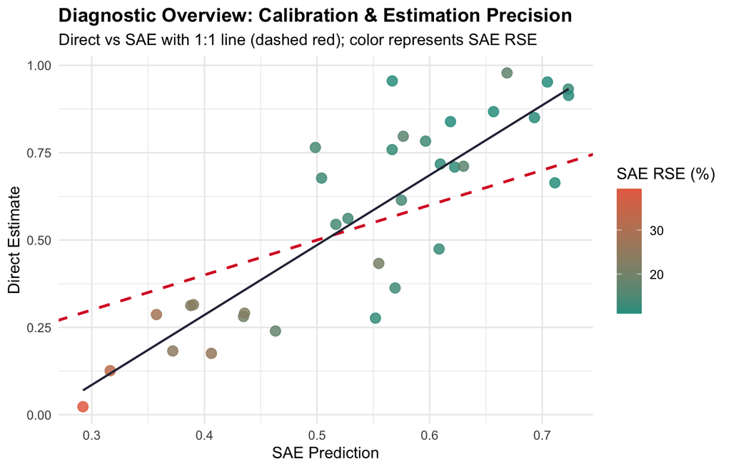

Figure 1: Model diagnostic panels generated via autoplot.

```r
diag_beta <- diagnose(fit_beta)
autoplot(diag_beta)
```

Small area estimation in official statistics requires reconciling mathematical rigor with strict computational and operational constraints. fastsae resolves these challenges by bridging high-performance compiled linear algebra, deterministic Bayesian approximations, and production-ready dissemination tools.

The fastsae results in this paper were obtained using R 4.6.1 with fastsae 1.0.0, R-INLA 26.8.7, and ggplot2 4.0.3 on an Apple M4 processor; the comparison runs used sae 1.3, emdi 2.2, tipsae 1.0, and hbsae 1.2. R and packages from CRAN are available at . R-INLA is available from . The fastsae package is available on GitHub at .

The authors thank the Department of Computational Statistics and Department of Statistics at Politeknik Statistika STIS for institutional support. We also acknowledge the valuable domain feedback provided by colleagues at BPS-Statistics Indonesia.

### 1 CRAN packages used

fastsae, sae, emdi, tipsae, mcmcsae, SUMMER, RcppArmadillo, RcppEigen, reticulate, bench, ggplot2, hbsae

### 2 CRAN Task Views implied by cited packages

Bayesian, ChemPhys, Cluster, HighPerformanceComputing, ModelDeployment, NetworkAnalysis, NumericalMathematics, OfficialStatistics, Phylogenetics, Spatial, TeachingStatistics